# Random Forest

# Tarea 5.

# Metodos supervisados

Librerias

```r
library(caTools)
library(rpart)
library(randomForest)
```

```r
library(ggplot2)
library(rpart.plot)
library(ROCR)
```

1. Desarolle el análisis del problema.
2. Cargue el archivo agaricus_lepiota.data.csv en una variable.
3. Desarolle el entendimiento de los datos.
4. Utilizando barplot cree un gráfico de los atributos del dataset, observe las correlaciones entre atributos.
5. Realice al menos 3 modelos vistos en clase.
6. Evaluación del modelo.
7. Desarolle al menos 3 conclusiones sobre las clasificaciones de los modelos.

## Análisis del Problema

Este conjunto de datos incluye descripciones de muestras hipotéticas correspondientes a 23 especies de hongos branquiales en el hongo de la familia Agaricus y Lepiota extraídas de la Guía de campo de la Sociedad Audubon de hongos de América del Norte (1981). Cada especie se identifica como definitivamente comestible, definitivamente venenosa o de comestibilidad desconocida y no se recomienda. Esta última clase se combinó con la venenosa. La Guía establece claramente que no existe una regla simple para determinar la comestibilidad de un hongo; ninguna regla como “folletos tres, que así sea” para el roble venenoso y la hiedra.

**Fuente del dataset**: https://archive.ics.uci.edu/ml/machine-learning-databases/mushroom/agaricus-lepiota.data

**Fuente del dataset expandido**: https://archive.ics.uci.edu/ml/machine-learning-databases/mushroom/expanded.Z

El conjunto de datos se encuentra conformado por las siguientes 23 variables y sus posibles valores (en inglés):

- **class**: edible = e, poisonous = p
- **cap-shape**: bell = b, conical = c, convex = x, flat = f, knobbed = k, sunken = s
- **cap-surface**: fibrous = f, grooves = g, scaly = y, smooth = s
- **cap-color**: brown = n, buff = b, cinnamon = c, gray = g, green = r, pink = p, purple = u, red = e, white = w, yellow = y
- **bruises**: bruises = t, no = f
- **odor**: almond = a, anise = l, creosote = c, fishy = y, foul = f, musty = m, none = n, pungent = p, spicy = s
- **gill-attachment**: attached = a, descending = d, free = f, notched = n
- **gill-spacing**: close = c, crowded = w, distant = d
- **gill-size**: broad = b, narrow = n
- **gill-color**: black = k, brown = n, buff = b, chocolate = h, gray = g, green = r, orange = o, pink = p, purple = u, red = e, white = w, yellow = y
- **stalk-shape**: enlarging = e, tapering = t
- **stalk-root**: bulbous = b, club = c, cup = u, equal = e, rhizomorphs = z, rooted = r, missing = ?
- **stalk-surface-above-ring**: fibrous = f, scaly = y, silky = k, smooth = s
- **stalk-surface-below-ring**: fibrous = f, scaly = y, silky = k, smooth = s
- **stalk-color-above-ring**: brown = n, buff = b, cinnamon = c, gray = g, orange = o, pink = p, red = e, white = w, yellow = y
- **stalk-color-below-ring**: brown = n, buff = b, cinnamon = c, gray = g, orange = o, pink = p, red = e, white = w, yellow = y
- **veil-type**: partial = p, universal = u
- **veil-color**: brown = n, orange = o, white = w, yellow = y
- **ring-number**: none = n, one = o, two = t
- **ring-type**: cobwebby = c, evanescent = e, flaring = f, large = l, none = n, pendant = p, sheathing = s, zone = z
- **spore-print-color**: black = k, brown = n, buff = b, chocolate = h, green = r, orange = o, purple = u, white = w, yellow = y
- **population**: abundant = a, clustered = c, numerous = n, scattered = s, several = v, solitary = y
- **habitat**: grasses = g, leaves = l, meadows = m, paths = p, urban = u, waste = w, woods = d

Como se observa para cada una de las variables, existe una definición de códigos por attributo que permite comprimir mejor los datos y reducir el espacio del archivo (en el caso del dataset original). A su vez existe un dataset expandido con mayor detalle del valor de cada uno de las variables en el dataset.

Se prentende usar este dataset para realizar varios modelos de clasificación supervisados y poder sacar conclusiones al respecto de los datos y las ventajas/desventajas de cada uno de los modelos empleados. La idea final de cada modelo es poder identificar según los atributos empleados, si un hongo es comestible o venenoso.

## Carga de Datos

Para la carga de los datos por analizar se utilizó el archivo con formato expandido para poder poseer un mayor detalle de cada uno de los elementos almacenados según las variables y así no estar pendiente de la traducción de la codificación presentada en el archivo original. Además, este archivo presenta una mayor cantidad de datos registrados que el archivo con el formato codificado.

```r
data_hongos <- read.csv("expanded.txt",
                        header = FALSE, # El archivo no posee cabecera.
                        stringsAsFactors = TRUE, # Convierte las variables categóricas en factor.
                        skip = 9, # Los datos empiezan en la línea 10.
                        nrows = 8416, # Cantidad total de registros.
                        col.names = c("class", "cap-shape", "cap-surface", "cap-color", "bruises", "odor",
                                      "gill-attachment", "gill-spacing", "gill-size", "gill-color",
                                      "stalk-shape", "stalk-root", "stalk-surface-above-ring",
                                      "stalk-surface-below-ring",  "stalk-color-above-ring",
                                      "stalk-color-below-ring", "veil-type", "veil-color", "ring-number",
                                      "ring-type", "spore-print-color", "population", "habitat"))
```

## Entendimiento de los Datos

Vamos a observar la estructura actual de los datos.

```r
str(data_hongos)
```

```
## 'data.frame':    8416 obs. of  23 variables:
##  $ class                   : Factor w/ 2 levels "EDIBLE","POISONOUS": 1 1 1 1 1 1 1 1 1 1 ...
##  $ cap.shape               : Factor w/ 6 levels "BELL","CONICAL",..: 3 3 3 3 3 3 3 3 3 3 ...
##  $ cap.surface             : Factor w/ 4 levels "FIBROUS","GROOVES",..: 4 4 4 4 4 4 4 4 4 4 ...
##  $ cap.color               : Factor w/ 10 levels "BROWN","BUFF",..: 9 9 9 9 9 9 9 9 9 9 ...
##  $ bruises                 : Factor w/ 2 levels "BRUISES","NO": 1 1 1 1 1 1 1 1 1 1 ...
##  $ odor                    : Factor w/ 9 levels "ALMOND","ANISE",..: 1 1 1 1 1 1 2 2 2 2 ...
##  $ gill.attachment         : Factor w/ 2 levels "ATTACHED","FREE": 2 2 2 2 2 2 2 2 2 2 ...
##  $ gill.spacing            : Factor w/ 2 levels "CLOSE","CROWDED": 2 2 2 2 2 2 2 2 2 2 ...
##  $ gill.size               : Factor w/ 2 levels "BROAD","NARROW": 2 2 2 2 2 2 2 2 2 2 ...
##  $ gill.color              : Factor w/ 12 levels "BLACK","BROWN",..: 11 11 8 8 2 2 11 11 8 8 ...
##  $ stalk.shape             : Factor w/ 2 levels "ENLARGING","TAPERING": 2 2 2 2 2 2 2 2 2 2 ...
##  $ stalk.root              : Factor w/ 5 levels "?","BULBOUS",..: 2 2 2 2 2 2 2 2 2 2 ...
##  $ stalk.surface.above.ring: Factor w/ 4 levels "FIBROUS","SCALY",..: 4 4 4 4 4 4 4 4 4 4 ...
##  $ stalk.surface.below.ring: Factor w/ 4 levels "FIBROUS","SCALY",..: 4 4 4 4 4 4 4 4 4 4 ...
##  $ stalk.color.above.ring  : Factor w/ 9 levels "BROWN","BUFF",..: 8 8 8 8 8 8 8 8 8 8 ...
##  $ stalk.color.below.ring  : Factor w/ 9 levels "BROWN","BUFF",..: 8 8 8 8 8 8 8 8 8 8 ...
##  $ veil.type               : Factor w/ 1 level "PARTIAL": 1 1 1 1 1 1 1 1 1 1 ...
##  $ veil.color              : Factor w/ 4 levels "BROWN","ORANGE",..: 3 3 3 3 3 3 3 3 3 3 ...
##  $ ring.number             : Factor w/ 3 levels "NONE","ONE","TWO": 2 2 2 2 2 2 2 2 2 2 ...
##  $ ring.type               : Factor w/ 5 levels "EVANESCENT","FLARING",..: 5 5 5 5 5 5 5 5 5 5 ...
##  $ spore.print.color       : Factor w/ 9 levels "BLACK","BROWN",..: 7 2 7 2 7 2 7 2 7 2 ...
##  $ population              : Factor w/ 6 levels "ABUNDANT","CLUSTERED",..: 5 5 5 5 5 5 5 5 5 5 ...
##  $ habitat                 : Factor w/ 7 levels "GRASSES","LEAVES",..: 7 7 7 7 7 7 7 7 7 7 ...
```

Como se muestra previamente, se poseen 8416 observaciones con 23 variables categóricas por cada uno de los registros.

```r
summary(data_hongos)
```

```
##        class        cap.shape     cap.surface     cap.color
##  EDIBLE   :4488   BELL   : 452   FIBROUS:2460   BROWN  :2320
##  POISONOUS:3928   CONICAL:   4   GROOVES:   4   GRAY   :2096
##                   CONVEX :3796   SCALY  :3268   RED    :1500
##                   FLAT   :3292   SMOOTH :2684   YELLOW :1072
##                   KNOBBED: 840                  WHITE  :1040
##                   SUNKEN :  32                  BUFF   : 168
##                                                 (Other): 220
##     bruises          odor      gill.attachment  gill.spacing
##  BRUISES:3376   NONE   :3808   ATTACHED: 216   CLOSE  :6824
##  NO     :5040   FOUL   :2160   FREE    :8200   CROWDED:1592
##                 FISHY  : 576
##                 SPICY  : 576
##                 ALMOND : 400
##                 ANISE  : 400
##                 (Other): 496
##   gill.size        gill.color      stalk.shape     stalk.root
##  BROAD :5880   BUFF     :1728   ENLARGING:3552   ?      :2480
##  NARROW:2536   PINK     :1556   TAPERING :4864   BULBOUS:3800
##                WHITE    :1232                    CLUB   : 568
##                BROWN    :1112                    EQUAL  :1376
##                CHOCOLATE: 796                    ROOTED : 192
##                GRAY     : 752
##                (Other)  :1240
##  stalk.surface.above.ring stalk.surface.below.ring stalk.color.above.ring
##  FIBROUS: 692             FIBROUS: 740             WHITE  :4744
##  SCALY  :  24             SCALY  : 296             PINK   :1872
##  SILKY  :2384             SILKY  :2304             GRAY   : 576
##  SMOOTH :5316             SMOOTH :5076             BROWN  : 448
##                                                    BUFF   : 432
##                                                    ORANGE : 192
##                                                    (Other): 152
##  stalk.color.below.ring   veil.type     veil.color   ring.number
##  WHITE  :4640           PARTIAL:8416   BROWN :  96   NONE:  48
##  PINK   :1872                          ORANGE:  96   ONE :7768
##  GRAY   : 576                          WHITE :8216   TWO : 600
##  BROWN  : 536                          YELLOW:   8
##  BUFF   : 432
##  ORANGE : 192
##  (Other): 168
##       ring.type    spore.print.color     population      habitat
##  EVANESCENT:3056   WHITE    :2424    ABUNDANT : 512   GRASSES:2404
##  FLARING   :  48   BROWN    :2096    CLUSTERED: 352   LEAVES : 856
##  LARGE     :1296   BLACK    :2000    NUMEROUS : 400   MEADOWS: 292
##  NONE      :  48   CHOCOLATE:1632    SCATTERED:1376   PATHS  :1144
##  PENDANT   :3968   GREEN    :  72    SEVERAL  :4064   URBAN  : 368
##                    BUFF     :  48    SOLITARY :1712   WASTE  : 192
##                    (Other)  : 144                     WOODS  :3160
```

Al realizar una sumarización de los datos se pueden observar datos interesantes como los siguientes:

- Las observaciones se dividen 4488 en **comestibles** (53.33%) y 3928 en **venenosas** (46.67%).
- El tipo de velo (veil.type) solo posee observaciones del tipo **partial**.
- La mayoría de los registros pertenecen a los hábitats **woods** (3160) y **grasses** (2404).

A continuación vamos a observar el comportamiento de las variables según si las observaciones son de tipo venenosas o comestibles (variable **class**).

```r
table(data_hongos$class, data_hongos$cap.shape)
```

```
##
##             BELL CONICAL CONVEX FLAT KNOBBED SUNKEN
##   EDIBLE     404       0   2084 1732     236     32
##   POISONOUS   48       4   1712 1560     604      0
```

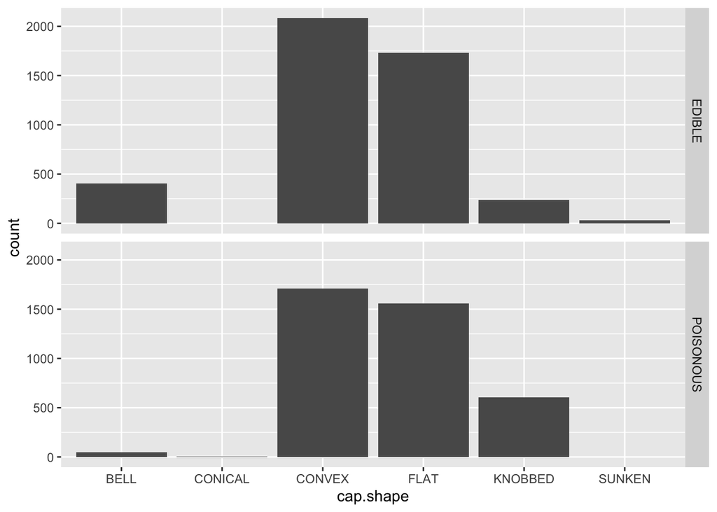

```r
ggplot(data_hongos, aes(x = cap.shape)) +
  geom_histogram(stat = "count") +
  facet_grid(c("class"))
```

Se observa una ligera diferencia al comparar el **cap.shape** (principalmente en los valores de **bell**, **knobbed** y **sunken**). Podría ser interesante de emplear en el modelo en conjunto a otras variables.

```r
table(data_hongos$class, data_hongos$cap.surface)
```

```
##
##             FIBROUS GROOVES SCALY SMOOTH
##   EDIBLE       1700       0  1516   1272
##   POISONOUS     760       4  1752   1412
```

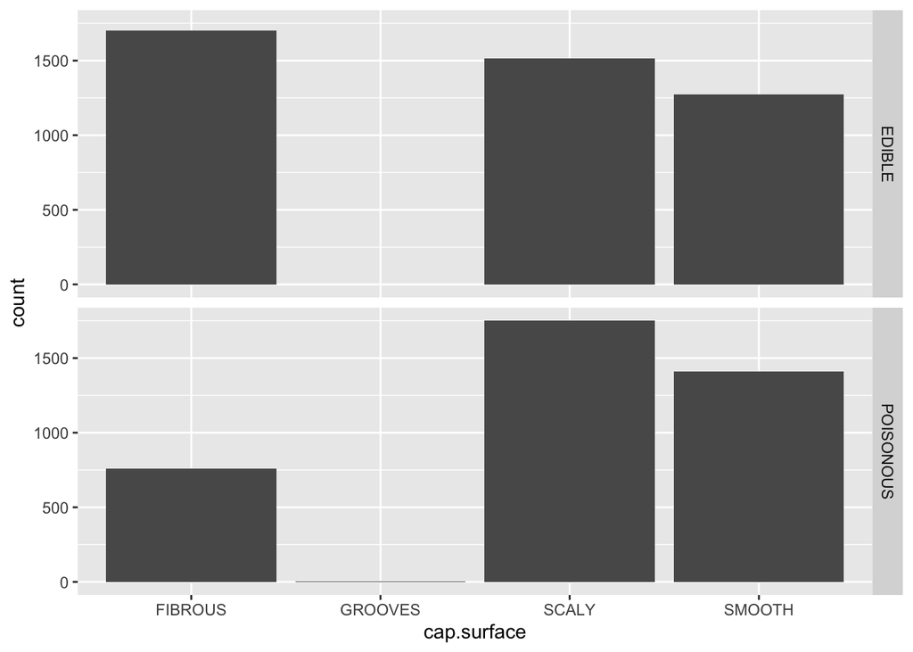

```r
ggplot(data_hongos, aes(x = cap.surface)) +
  geom_histogram(stat = "count") +
  facet_grid(c("class"))
```

Del mismo modo se observa una ligera diferencia al comparar el **cap.surface** (principalmente en el valor **fibrous**). Podría ser interesante de emplear en el modelo en conjunto a otras variables.

```r
table(data_hongos$class, data_hongos$cap.color)
```

```
##
##             BROWN BUFF CINNAMON GRAY GREEN PINK PURPLE  RED WHITE YELLOW
##   EDIBLE     1288   48       32 1288    16   56     16  624   720    400
##   POISONOUS  1032  120       12  808     0   88      0  876   320    672
```

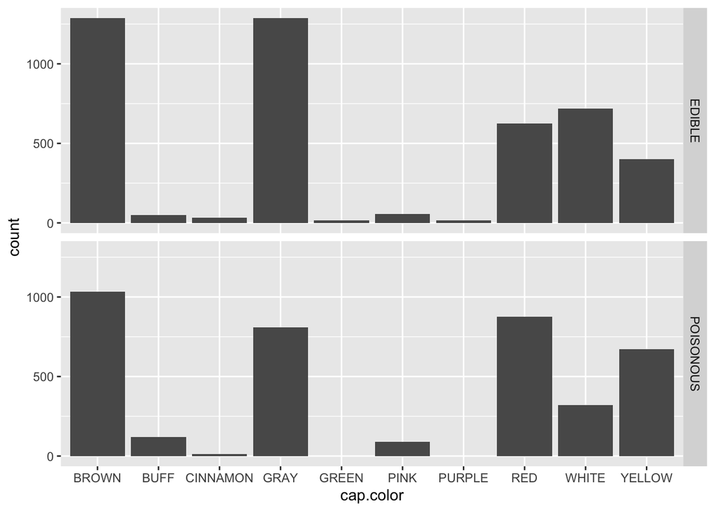

```r
ggplot(data_hongos, aes(x = cap.color)) +
  geom_histogram(stat = "count") +
  facet_grid(c("class"))
```

En el caso de **cap.color** se nota una variabilidad interesante entre la distribución de colores.

```r
table(data_hongos$class, data_hongos$bruises)
```

```
##
##             BRUISES   NO
##   EDIBLE       2752 1736
##   POISONOUS     624 3304
```

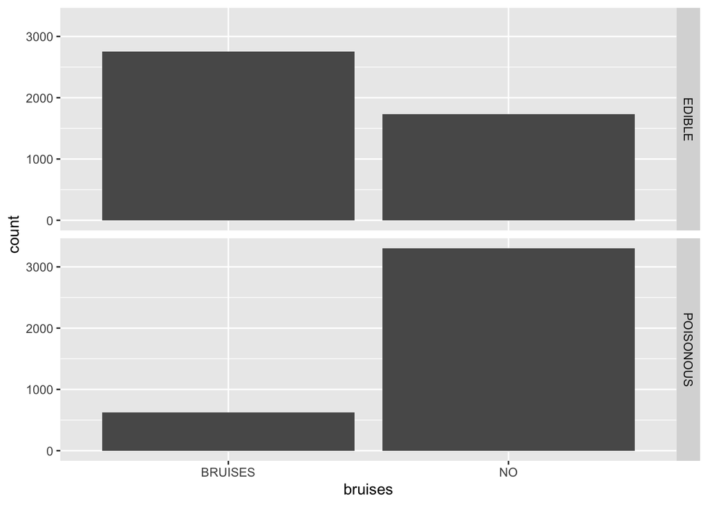

```r
ggplot(data_hongos, aes(x = bruises)) +
  geom_histogram(stat = "count") +
  facet_grid(c("class"))
```

Se observa una diferencia significativa al comparar **bruises** entre si un hongo es comestible o no.

```r
table(data_hongos$class, data_hongos$odor)
```

```
##
##             ALMOND ANISE CREOSOTE FISHY FOUL MUSTY NONE PUNGENT SPICY
##   EDIBLE       400   400        0     0    0     0 3688       0     0
##   POISONOUS      0     0      192   576 2160    48  120     256   576
```

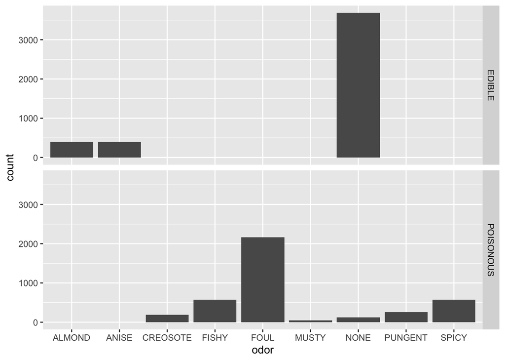

```r
ggplot(data_hongos, aes(x = odor)) +
  geom_histogram(stat = "count") +
  facet_grid(c("class"))
```

Del mismo modo, se observa una diferencia significativa al comparar **odor** entre si un hongo es comestible o no.

```r
table(data_hongos$class, data_hongos$gill.attachment)
```

```
##
##             ATTACHED FREE
##   EDIBLE         192 4296
##   POISONOUS       24 3904
```

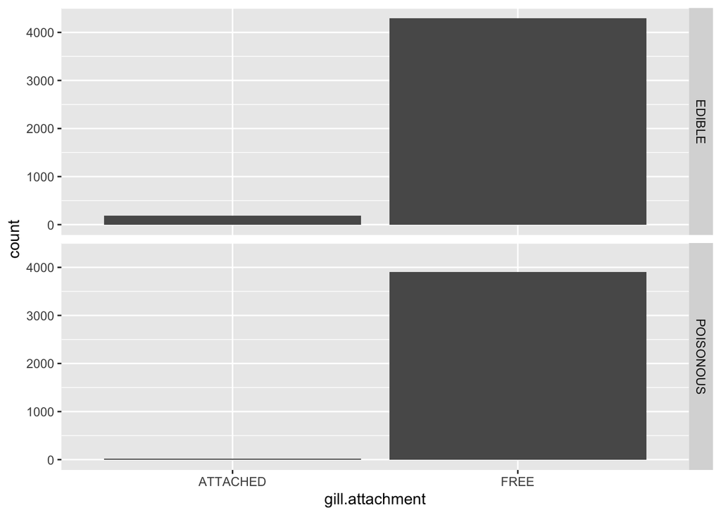

```r
ggplot(data_hongos, aes(x = gill.attachment)) +
  geom_histogram(stat = "count") +
  facet_grid(c("class"))
```

No se observa una diferencia significativa al comparar **gill.attachment**.

```r
table(data_hongos$class, data_hongos$gill.spacing)
```

```
##
##             CLOSE CROWDED
##   EDIBLE     3008    1480
##   POISONOUS  3816     112
```

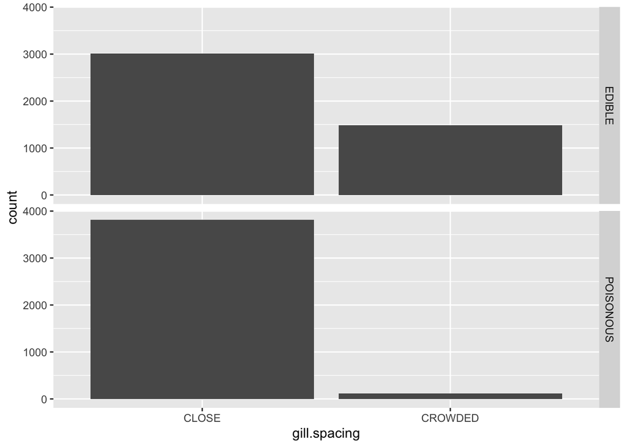

```r
ggplot(data_hongos, aes(x = gill.spacing)) +
  geom_histogram(stat = "count") +
  facet_grid(c("class"))
```

Se observa una ligera diferencia al comparar el **gill.spacing**. Podría ser interesante de emplear en el modelo en conjunto a otras variables.

```r
table(data_hongos$class, data_hongos$gill.size)
```

```
##
##             BROAD NARROW
##   EDIBLE     4176    312
##   POISONOUS  1704   2224
```

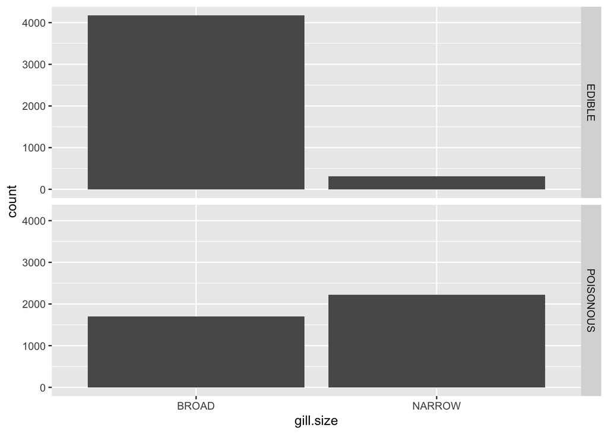

```r
ggplot(data_hongos, aes(x = gill.size)) +
  geom_histogram(stat = "count") +
  facet_grid(c("class"))
```

Del mismo modo, se observa una ligera diferencia al comparar el **gill.size**.

```r
table(data_hongos$class, data_hongos$gill.color)
```

```
##
##             BLACK BROWN BUFF CHOCOLATE GRAY GREEN ORANGE PINK PURPLE  RED
##   EDIBLE      408  1000    0       268  248     0     64  916    444   96
##   POISONOUS    64   112 1728       528  504    24      0  640     48    0
##
##             WHITE YELLOW
##   EDIBLE      980     64
##   POISONOUS   252     28
```

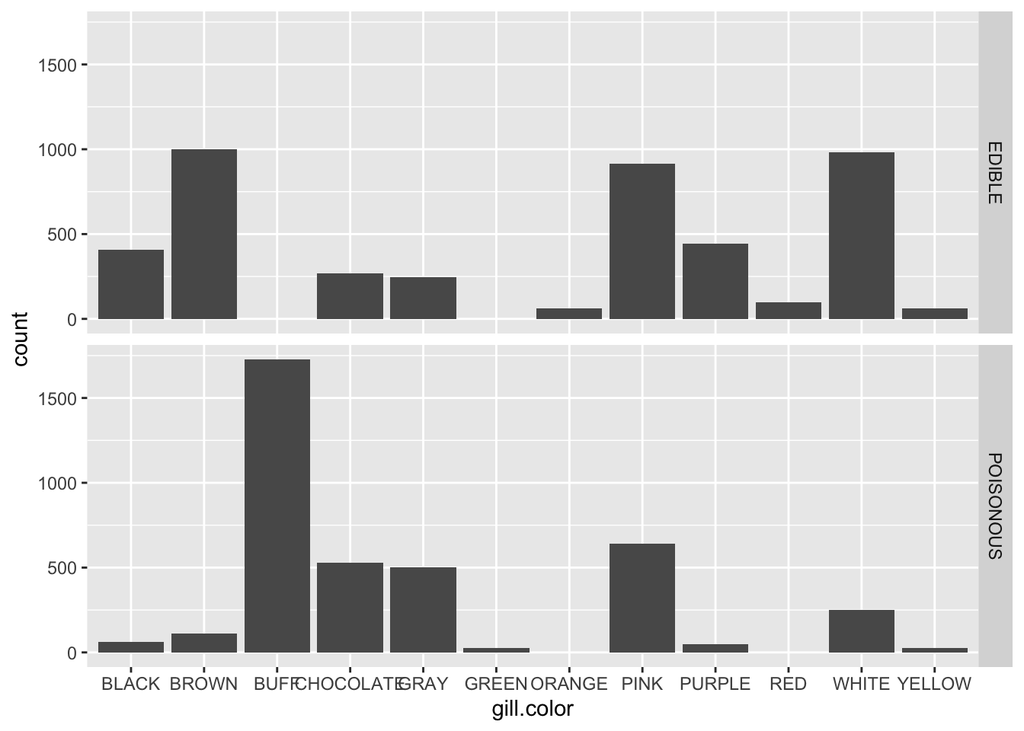

```r
ggplot(data_hongos, aes(x = gill.color)) +
  geom_histogram(stat = "count") +
  facet_grid(c("class"))
```

En el caso de **gill.color** se nota una variabilidad interesante entre la distribución de colores.

```r
table(data_hongos$class, data_hongos$stalk.shape)
```

```
##
##             ENLARGING TAPERING
##   EDIBLE         1640     2848
##   POISONOUS      1912     2016
```

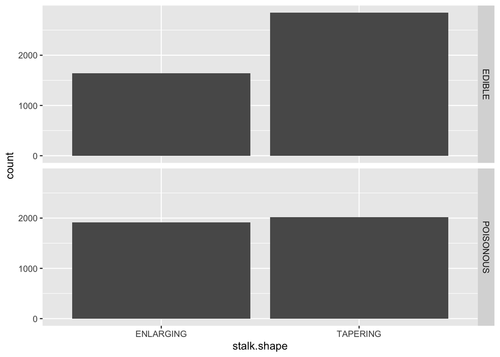

```r
ggplot(data_hongos, aes(x = stalk.shape)) +
  geom_histogram(stat = "count") +
  facet_grid(c("class"))
```

No se observa una diferencia significativa al comparar **stalk.shape**.

```r
table(data_hongos$class, data_hongos$stalk.root)
```

```
##
##                ? BULBOUS CLUB EQUAL ROOTED
##   EDIBLE     720    1944  512  1120    192
##   POISONOUS 1760    1856   56   256      0
```

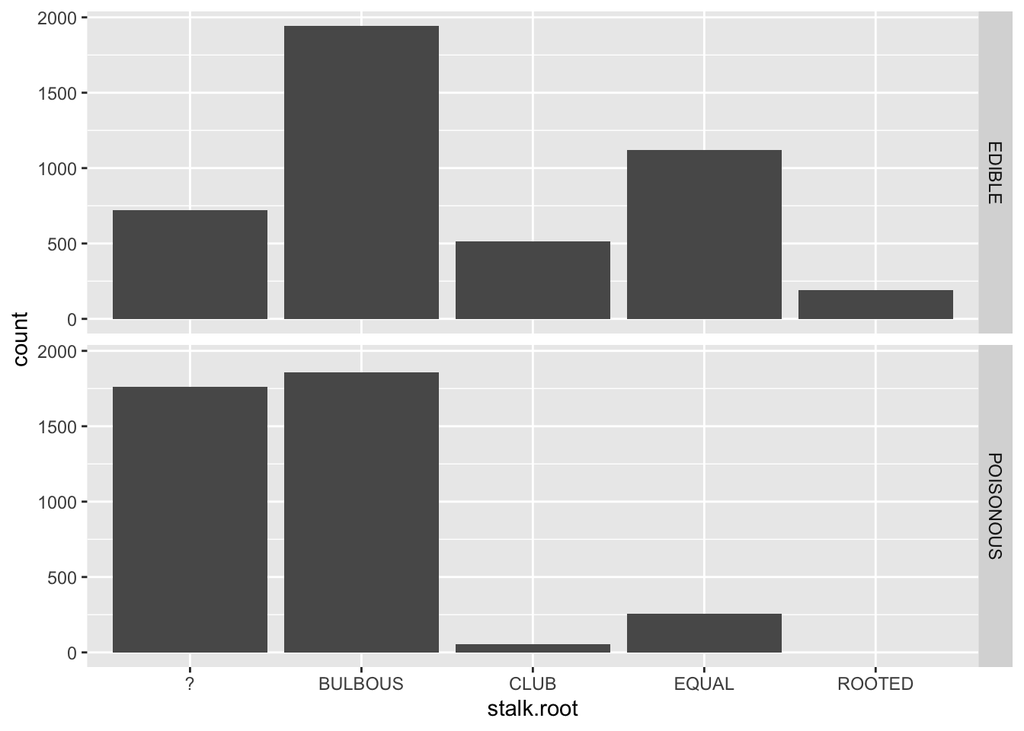

```r
ggplot(data_hongos, aes(x = stalk.root)) +
  geom_histogram(stat = "count") +
  facet_grid(c("class"))
```

Se observa una ligera diferencia al comparar el **stalk.root**. Podría ser interesante de emplear en el modelo en conjunto a otras variables.

```r
table(data_hongos$class, data_hongos$stalk.surface.above.ring)
```

```
##
##             FIBROUS SCALY SILKY SMOOTH
##   EDIBLE        548    16   144   3780
##   POISONOUS     144     8  2240   1536
```

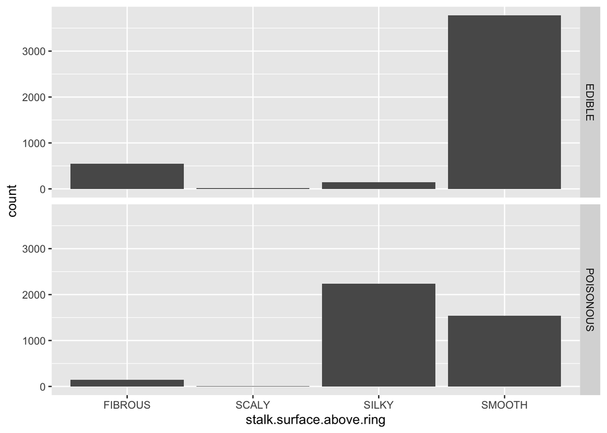

```r
ggplot(data_hongos, aes(x = stalk.surface.above.ring)) +
  geom_histogram(stat = "count") +
  facet_grid(c("class"))
```

Se observa una ligera diferencia al comparar el **stalk.surface.above.ring** (principalmente en los valores de **silky** y **smooth**).

```r
table(data_hongos$class, data_hongos$stalk.surface.below.ring)
```

```
##
##             FIBROUS SCALY SILKY SMOOTH
##   EDIBLE        596   208   144   3540
##   POISONOUS     144    88  2160   1536
```

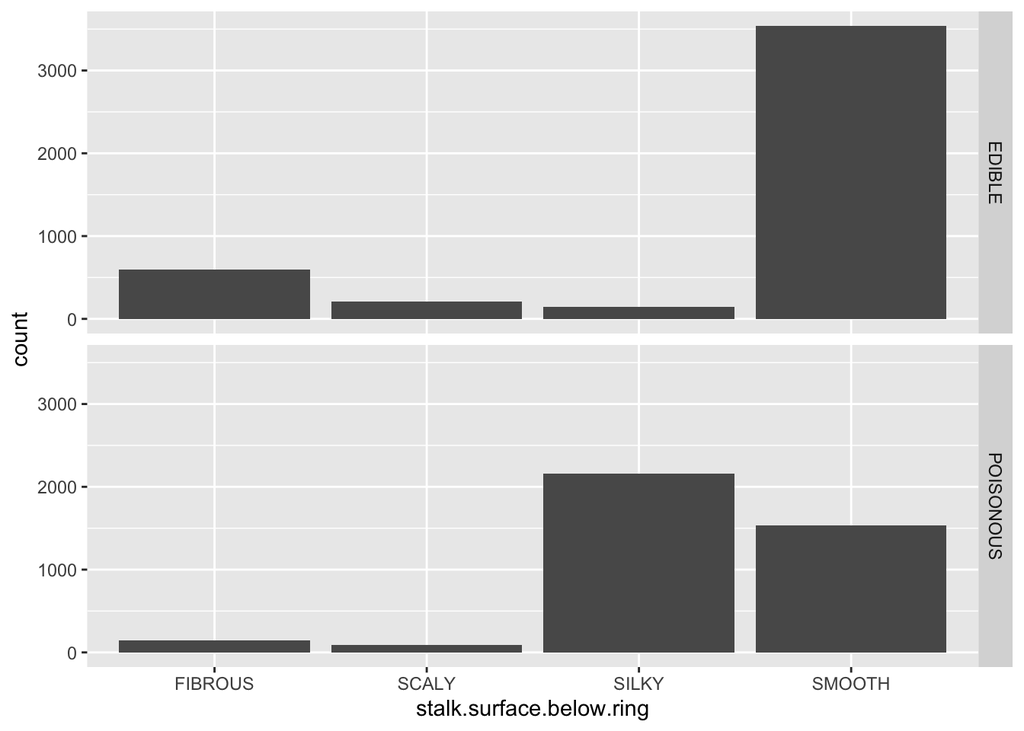

```r
ggplot(data_hongos, aes(x = stalk.surface.below.ring)) +
  geom_histogram(stat = "count") +
  facet_grid(c("class"))
```

Del mismo modo para **stalk.surface.below.ring**. Pero estas dos son muy similares entre si, por lo que se puede escoger una de las 2 para los modelos.

```r
table(data_hongos$class, data_hongos$stalk.color.above.ring)
```

```
##
##             BROWN BUFF CINNAMON GRAY ORANGE PINK  RED WHITE YELLOW
##   EDIBLE       16    0        0  576    192  576   96  3032      0
##   POISONOUS   432  432       48    0      0 1296    0  1712      8
```

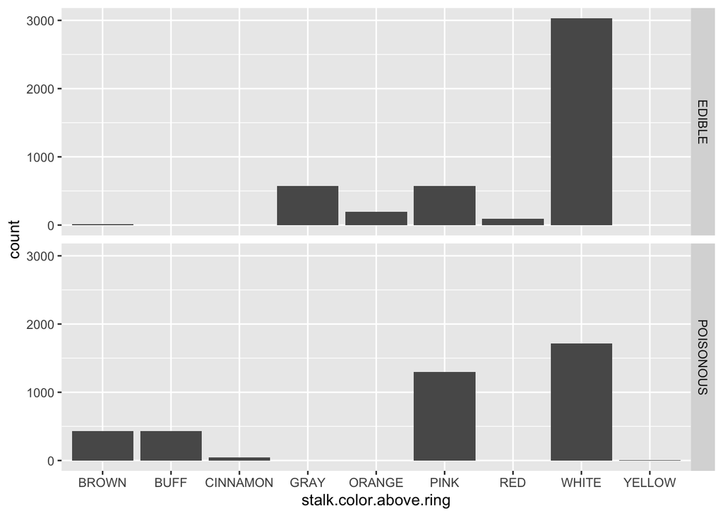

```r
ggplot(data_hongos, aes(x = stalk.color.above.ring)) +
  geom_histogram(stat = "count") +
  facet_grid(c("class"))
```

```r
table(data_hongos$class, data_hongos$stalk.color.below.ring)
```

```
##
##             BROWN BUFF CINNAMON GRAY ORANGE PINK  RED WHITE YELLOW
##   EDIBLE       88    0        0  576    192  576   96  2960      0
##   POISONOUS   448  432       48    0      0 1296    0  1680     24
```

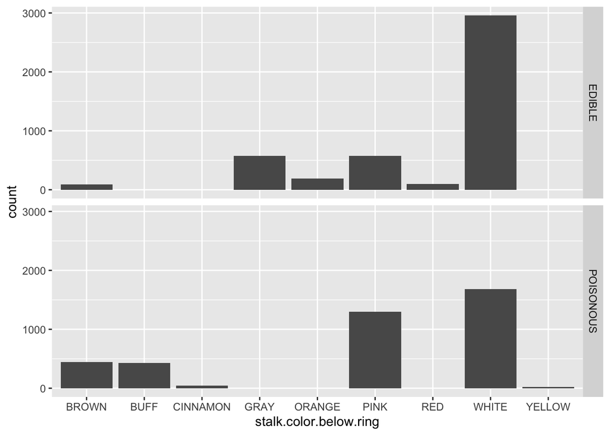

```r
ggplot(data_hongos, aes(x = stalk.color.below.ring)) +
  geom_histogram(stat = "count") +
  facet_grid(c("class"))
```

Se observa una diferencia significativa al comparar **stalk.color.above.ring** y **stalk.color.below.ring** entre si un hongo es comestible o no. Pero entre ellas son muy similares, por lo que para el modelo se podría emplear solamente una de las dos.

```r
table(data_hongos$class, data_hongos$veil.type)
```

```
##
##             PARTIAL
##   EDIBLE       4488
##   POISONOUS    3928
```

Como se mencionó previamente, todas las observaciones en el caso del atributo **veil.type** son **partial**. Por lo que quizás no sea necesaria para el modelo.

```r
table(data_hongos$class, data_hongos$veil.color)
```

```
##
##             BROWN ORANGE WHITE YELLOW
##   EDIBLE       96     96  4296      0
##   POISONOUS     0      0  3920      8
```

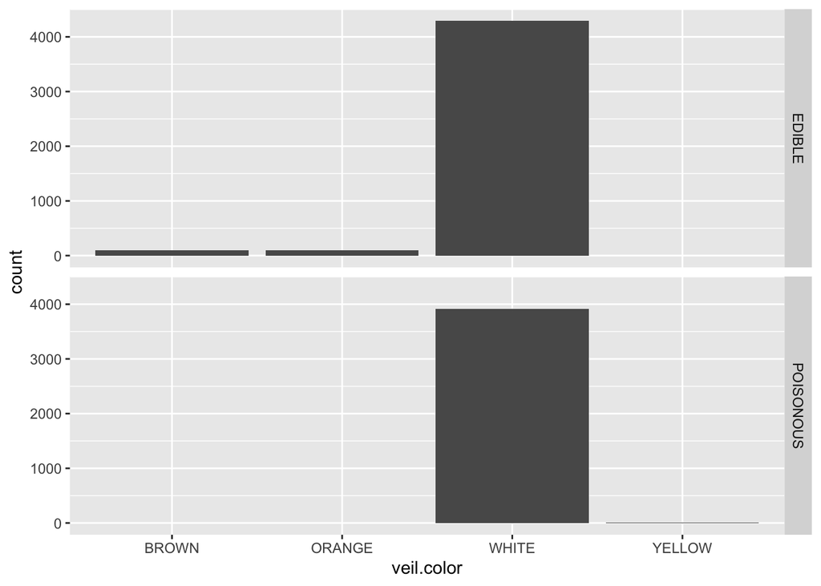

```r
ggplot(data_hongos, aes(x = veil.color)) +
  geom_histogram(stat = "count") +
  facet_grid(c("class"))
```

Se observa una ligera diferencia al comparar el **veil.color**.

```r
table(data_hongos$class, data_hongos$ring.number)
```

```
##
##             NONE  ONE  TWO
##   EDIBLE       0 3960  528
##   POISONOUS   48 3808   72
```

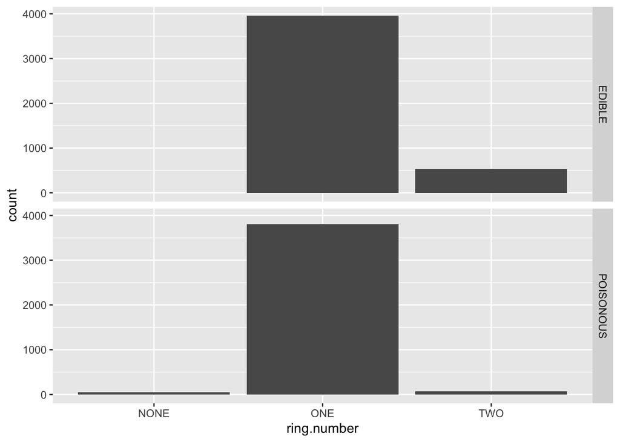

```r
ggplot(data_hongos, aes(x = ring.number)) +
  geom_histogram(stat = "count") +
  facet_grid(c("class"))
```

No se observa una diferencia significativa al comparar **ring.number**.

```r
table(data_hongos$class, data_hongos$ring.type)
```

```
##
##             EVANESCENT FLARING LARGE NONE PENDANT
##   EDIBLE          1288      48     0    0    3152
##   POISONOUS       1768       0  1296   48     816
```

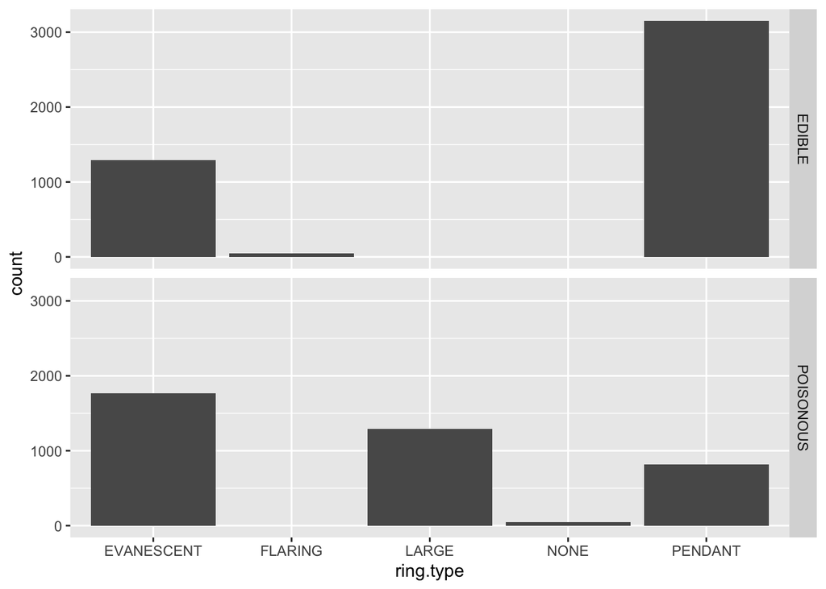

```r
ggplot(data_hongos, aes(x = ring.type)) +
  geom_histogram(stat = "count") +
  facet_grid(c("class"))
```

Pero sí es relativamente significativa en el caso de **ring.type**.

```r
table(data_hongos$class, data_hongos$spore.print.color)
```

```
##
##             BLACK BROWN BUFF CHOCOLATE GREEN ORANGE PURPLE WHITE YELLOW
##   EDIBLE     1776  1872   48        48     0     48     48   600     48
##   POISONOUS   224   224    0      1584    72      0      0  1824      0
```

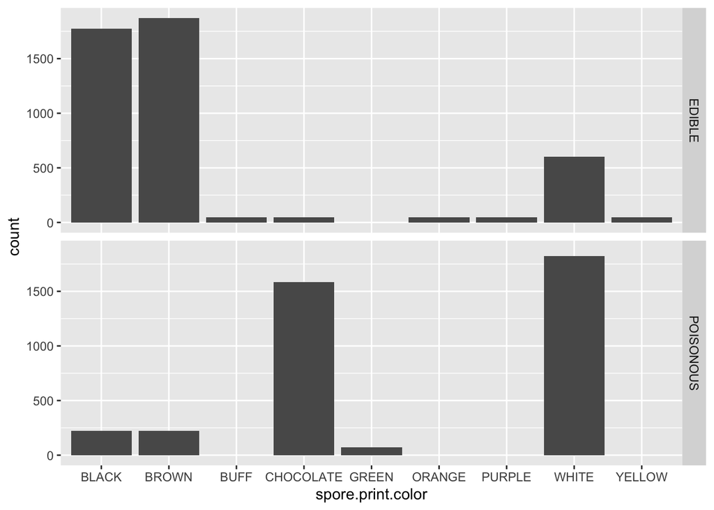

```r
ggplot(data_hongos, aes(x = spore.print.color)) +
  geom_histogram(stat = "count") +
  facet_grid(c("class"))
```

Se observa una diferencia significativa al comparar **spore.print.color** entre si un hongo es comestible o no.

```r
table(data_hongos$class, data_hongos$population)
```

```
##
##             ABUNDANT CLUSTERED NUMEROUS SCATTERED SEVERAL SOLITARY
##   EDIBLE         512       288      400      1008    1216     1064
##   POISONOUS        0        64        0       368    2848      648
```

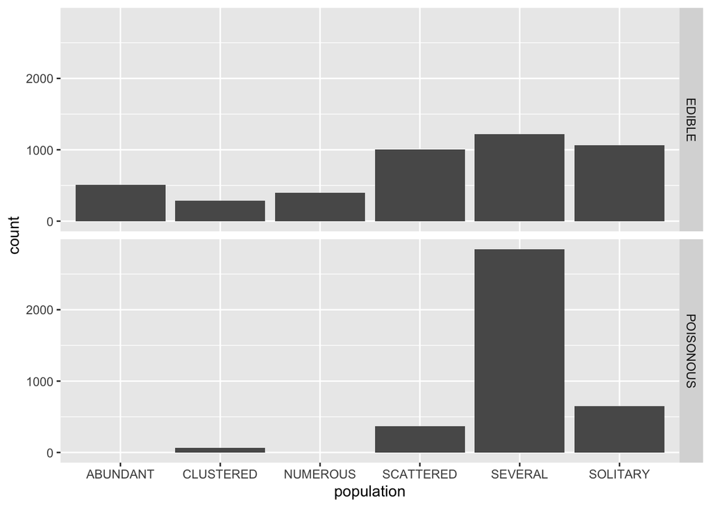

```r
ggplot(data_hongos, aes(x = population)) +
  geom_histogram(stat = "count") +
  facet_grid(c("class"))
```

Del mismo modo, al comparar **population** entre si un hongo es comestible o no.

```r
table(data_hongos$class, data_hongos$habitat)
```

```
##
##             GRASSES LEAVES MEADOWS PATHS URBAN WASTE WOODS
##   EDIBLE       1664    264     256   136    96   192  1880
##   POISONOUS     740    592      36  1008   272     0  1280
```

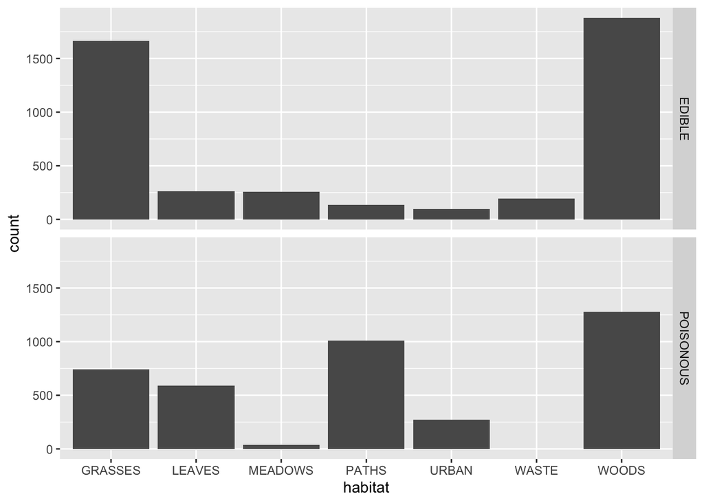

```r
ggplot(data_hongos, aes(x = habitat)) +
  geom_histogram(stat = "count") +
  facet_grid(c("class"))
```

Finalmente, se observa una ligera diferencia entre los valores del attributo **habitat**.

## Creación del Modelo

A continuación se van a crear 3 modelos distintos de agrupación supervisada: un **árbol de decisión**, un **random forest** y una **regresión logística**. Empecemos por dividir los datos aleatoriamente entre un conjunto para entrenamiento y otro para pruebas posteriores en la sección de evaluación del modelo.

```r
set.seed(123)
data_split <- sample.split(data_hongos$class, SplitRatio = 0.8)
data_hongos_train <- subset(data_hongos, data_split == TRUE)
data_hongos_test <- subset(data_hongos, data_split == FALSE)
```

Luego vamos a definir el modelo para el árbol de decisión. Para los tres modelos se va a utilizar la siguiente fórmula:

**class = cap.shape + cap.surface + cap.color + bruises + odor + gill.spacing + gill.size + gill.color + stalk.root + stalk.surface.below.ring + stalk.color.below.ring + veil.color + ring.type + spore.print.color + population + habitat**

```r
arbol_decision_model <- rpart(class ~ cap.shape + cap.surface + cap.color + bruises + odor +
                                gill.spacing + gill.size + gill.color + stalk.root +
                                stalk.surface.below.ring + stalk.color.below.ring + veil.color +
                                ring.type + spore.print.color + population + habitat,
                              data = data_hongos_train,
                              method = "class")

arbol_decision_predicciones <- predict(arbol_decision_model,
                                       newdata = data_hongos_test,
                                       type = "class")
```

A continuación se crea el modelo random forest para el dataset de hongos.

```r
random_forest_model <- randomForest(class ~ cap.shape + cap.surface + cap.color + bruises + odor +
                                gill.spacing + gill.size + gill.color + stalk.root +
                                stalk.surface.below.ring + stalk.color.below.ring + veil.color +
                                ring.type + spore.print.color + population + habitat,
                                data = data_hongos_train)

random_forest_predicciones <- predict(random_forest_model,
                                      newdata = data_hongos_test,
                                      type = "class")
```

Finalmente, se crea el modelo para la regresión logística.

```r
regresion_logistica_model <- glm(class ~ cap.shape + cap.surface + cap.color + bruises + odor +
                                gill.spacing + gill.size + gill.color + stalk.root +
                                stalk.surface.below.ring + stalk.color.below.ring + veil.color +
                                ring.type + spore.print.color + population + habitat,
                                data = data_hongos_train,
                                family = binomial)
regresion_logistica_predicciones <- predict(regresion_logistica_model,
                                            newdata = data_hongos_test,
                                            type = "response")
```

## Evaluación del Modelo

Ahora vamos a analizar y evaluar que tan buenos resultaron los modelos empleados en la sección anterior. Empezando por el de árbol de decisión.

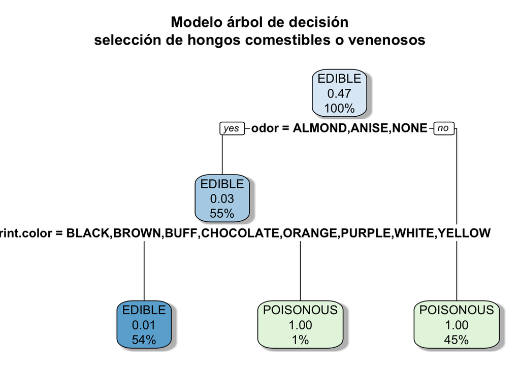

```r
rpart.plot(arbol_decision_model,
           shadow.col = "gray",
           main = "Modelo árbol de decisión\nselección de hongos comestibles o venenosos")
```

```r
table(data_hongos_test$class, arbol_decision_predicciones)
```

```
##            arbol_decision_predicciones
##             EDIBLE POISONOUS
##   EDIBLE       898         0
##   POISONOUS     11       775
```

```r
arbol_decision_predicciones_roc <- prediction(c(arbol_decision_predicciones), c(data_hongos_test$class))
as.numeric(performance(arbol_decision_predicciones_roc, measure = "auc")@y.values)
```

```
## [1] 0.9930025
```

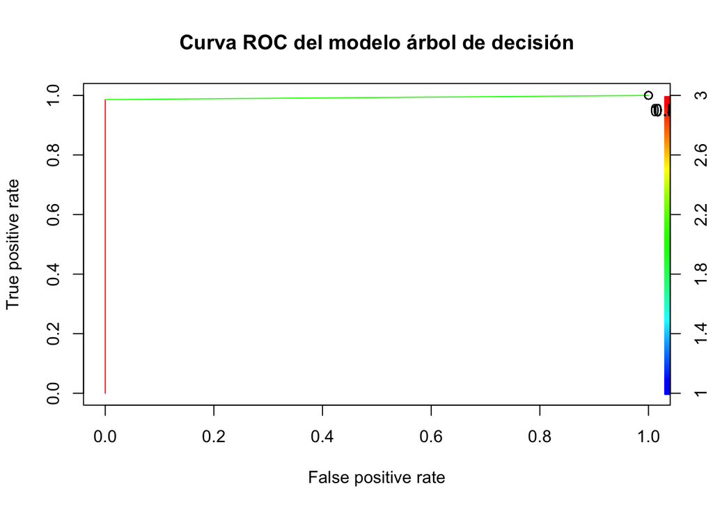

```r
plot(performance(arbol_decision_predicciones_roc, "tpr", "fpr"),
     colorize = T,
     print.cutoffs.at = seq(0, 1, by = 0.1),
     text.adj = c(-0.2, 1.7),
     main = 'Curva ROC del modelo árbol de decisión')
```

Luego evaluamos el modelo de random forest.

```r
table(data_hongos_test$class, random_forest_predicciones)
```

```
##            random_forest_predicciones
##             EDIBLE POISONOUS
##   EDIBLE       898         0
##   POISONOUS      0       786
```

```r
random_forest_predicciones_roc <- prediction(c(random_forest_predicciones), c(data_hongos_test$class))
as.numeric(performance(random_forest_predicciones_roc, measure = "auc")@y.values)
```

```
## [1] 1
```

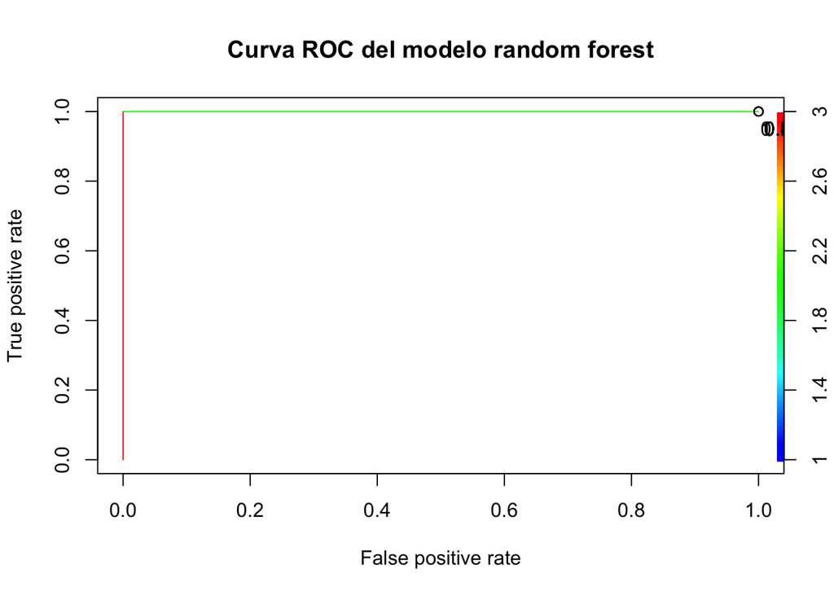

```r
plot(performance(random_forest_predicciones_roc, "tpr", "fpr"),
     colorize = T,
     print.cutoffs.at = seq(0, 1, by = 0.1),
     text.adj = c(-0.2, 1.7),
     main = 'Curva ROC del modelo random forest')
```

Finalmente, evaluamos el modelo de regresión logística.

```r
table(data_hongos_test$class, regresion_logistica_predicciones >= 0.8)
```

```
##
##             FALSE TRUE
##   EDIBLE      898    0
##   POISONOUS     0  786
```

```r
regresion_logistica_predicciones_roc <- prediction(c(regresion_logistica_predicciones), c(data_hongos_test$class))
as.numeric(performance(regresion_logistica_predicciones_roc, measure = "auc")@y.values)
```

```
## [1] 1
```

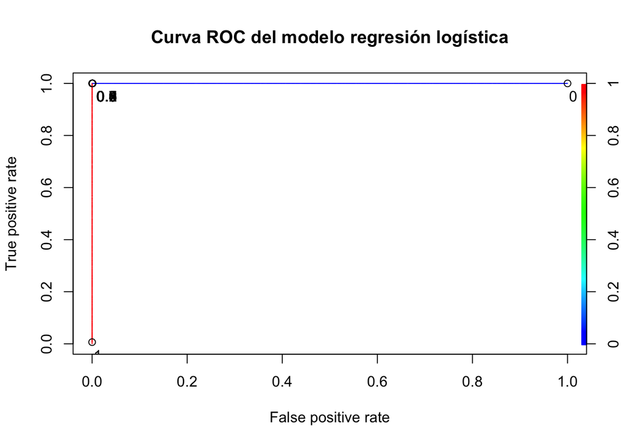

```r
plot(performance(regresion_logistica_predicciones_roc, "tpr", "fpr"),
     colorize = T,
     print.cutoffs.at = seq(0, 1, by = 0.1),
     text.adj = c(-0.2, 1.7),
     main = 'Curva ROC del modelo regresión logística')
```

## Conclusiones

Del desarrollo de los modelos se puede concluir lo siguiente:

- Los modelos **random forest** y **regresión logística** fueron muy robustos en la agrupación de los datos gracias a sus bondades: pocas suposiciones y preparación de los datos debido a la forma en el que se encontraba estructurado el dataset.
- A pesar de haber devuelto 11 falsos-positivos (hongos venenosos que agrupó como comestibles) el modelo **árbol de decisión** posee una confiabilidad alta (0.99). Aunque debido a la importancia de lo que se desea responder se debe tener cuidado al emplearlo en este caso (un error puede collevar a la intoxicación y muerte de una persona). Por lo tanto debe mejorarse el ajuste de los datos ya sea modificando la fórmula o ajustando los parámetros del modelo.
- En términos generales los tres modelos son bastante sencillos de emplear y requieren poca limpieza de los datos. No obstante el proceso de análisis de los datos sigue siendo primordial a la hora de aplicar cualquiera de estos modelos.
- Existe un poco de incertidumbre en los modelos **random forest** y **árbol de decisión** sobre temas como: interpretación de los datos, control de cómo se realiza la agrupación de los datos, y pérdida de información.